# Tutorial: Generalized Decomposition Priors on R2

Javier Aguilar and Paul Bürkner

2025-06-02

This document demonstrates how to fit models using different $R^2$ decomposition priors (including R2D2 and logit-R2 variants) with Stan via the cmdstanr interface.

# Load Libraries

```r
library(cmdstanr)
library(ggplot2)
library(bayesplot)
library(posterior)
library(tidyverse)
library(foreach)
library(future)
library(doFuture)
library(mvtnorm)
library(MASS)
library(patchwork)

source("utils/utils.R")
source("utils/cov_functions.R")
```

# Generate Data

We start by using the linear regression model as a generative model. The vector of coefficients $b$ has 10 nonzero elements set to the same value.

```r
n <- 250
ntest <- 500
p <- 25
rho <- 0.5
type <- c("ar")
R2 <- 0.8
seed <- 117

b_Intercept <- rnorm(1, 0, 5)[1]
b <- c(rep(5, 5), rep(0, p - 10), rep(5, 5))

covx <- gen_covmatrix(list(p = p, type = type, rho = rho))
sigma <- as.numeric(sqrt((1 - R2) / R2 * t(b) %*% covx %*% b))

X <- mvtnorm::rmvnorm(n, mean = rep(0, p), sigma = covx)
mu_train <- cbind(rep(1, n), X) %*% c(b_Intercept, b)
y <- rnorm(n, mu_train, sigma)

Xtest <- mvtnorm::rmvnorm(ntest, mean = rep(0, p), sigma = covx)
mu_test <- cbind(rep(1, ntest), Xtest) %*% c(b_Intercept, b)
ytest <- rnorm(ntest, mu_test, sigma)
```

# Simulation Parameters

```r
prior_only <- FALSE #sample only from the prior?

sim_params <- list(
  n = n,
  p = p,
  X = X,
  y = y,
  ntest = ntest,
  Xtest = Xtest,
  ytest = ytest,
  prior_only = prior_only,
  seed = seed,
  nchains = 4,
  iter_warmup = 1000,
  iter_sampling = 2000,
  adapt_delta = 0.95
)
```

# Fit Stan Models

In the following we use a function called “fit_model”, which takes the name of the Stan model, the simulation parameters, and “additional_params”, which is a list of additional fit-specific parameters as arguments.

## R2D2 Model

The R2D2 prior requires three parameters: the prior mean and precision of $R^2$, and the concentration vector $\alpha$. We typically set $\alpha = (a_{\pi}, \dots, a_{\pi})$ with $a_{\pi} > 0$, which simplifies the prior specification to three real valued hyperparameters. When $a_{\pi} \leq 0.5$, the resulting marginal prior distributions for the coefficients become unbounded at the origin, encouraging stronger shrinkage. To ensure that the marginal priors have heavy tails, we need to choose $a_2 = (1 - R2mean) R2prec \leq 0.5$.

```r
R2_mean <- 0.5
R2_prec <- 1
api <- 0.5

additional_params <- list(
  R2_mean = R2_mean,
  R2_prec = R2_prec,
  R2_alpha = rep(api, p)
)

fit_r2d2 <- fit_model(
  model_name = "r2d2",
  params = sim_params,
  additional_params = additional_params
)
```

## logitR2 (User-specified)

In the following, we show how to specify the parameters of the logit-R2 model. If the mean vector $\mu$ of the Logistic Normal (LN) distribution is set to zero and the covariance matrix $\Sigma$ is chosen as a diagonal matrix with entries $\sigma_{\eta}^2$, increasing $\sigma_{\eta}$ will exert stronger shrinkage. The script “plots/simplex_plots.R” visualizes the effect of different hyperparameter choices on the distribution over the simplex. While it is possible to use any covariance matrix $\Sigma$, interpretation becomes more challenging. For detailed guidance on specifying hyperparameters, please refer to the main paper.

The following code shows the version of the LN R2 prior that considers a softmax transformation. See “stan/models/logitR2.stan” for more information. Notice that “sigma_logitphi” is a Cholesky factor.

```r
mu_logitphi <- rep(0, p)
sigma_sd <- 1.5
sigma_logitphi <- chol(diag(sigma_sd, p))

additional_params <- list(
  R2_mean = 0.5,
  R2_prec = 1,
  mu_logitphi = mu_logitphi,
  sigma_logitphi = sigma_logitphi
)

fit_logitr2 <- fit_model(
  model_name = "logitR2",
  params = sim_params,
  additional_params = additional_params
)
```

## logitR2 (KL values)

We can also automate the specification of the hyperparameters of the Logistic Normal (LN) distribution (in the additive log-ratio (ALR) parametrization) by first selecting a Dirichlet distribution with concentration vector $\alpha$ and then finding the LN distribution that minimizes the Kullback–Leibler (KL) divergence to it. See the subsection on “Prior Matching” for more details.

The following code illustrates how to implement the LN R2 prior using the ALR transformation. See “stan/models/logitR2_alr.stan” for more information.

```r
api <- 0.5
alpha <- rep(api, p)

kl.params <- kl.diri.logitnormal(alpha = alpha, ref = 1)
mu_logitphi <- kl.params$mu
sigma_logitphi <- t(chol(kl.params$Sigma))

additional_params <- list(
  R2_mean = 0.5,
  R2_prec = 1,
  mu_logitphi = mu_logitphi,
  sigma_logitphi = sigma_logitphi
)

fit_logitr2_kl <- fit_model(
  model_name = "logitR2_alr",
  params = sim_params,
  additional_params = additional_params
)
```

## logitR2 (KL scales)

We can follow the same approach as before but focus solely on the scales (the diagonal entries) of the covariance matrix of the LN distribution that results from minimizing the KL divergence.

```r
api <- 0.5
alpha <- rep(api, p)

kl.params <- kl.diri.logitnormal(alpha = alpha, ref = 1)
mu_logitphi <- kl.params$mu
sigma_logitphi <- t(chol(diag(diag(kl.params$Sigma))))

additional_params <- list(
  R2_mean = 0.5,
  R2_prec = 1,
  mu_logitphi = mu_logitphi,
  sigma_logitphi = sigma_logitphi
)

fit_logitr2_kl_scales <- fit_model(
  model_name = "logitR2_alr",
  params = sim_params,
  additional_params = additional_params
)
```

## Relationship between DL and LN

When performing KL matching, if we choose a Dirichlet distribution with a symmetric concentration vector $\alpha = (a_{\pi}, \dots, a_{\pi} )$, the resulting mean of the Logistic Normal (LN) distribution will be a zero vector. Moreover, the scales (diagonal elements of the covariance matrix) of the LN distribution will all be equal. These are related via $\sigma_\eta = 2 *\textrm{Trigamma}(a_{\pi})$.

The plot below illustrates how these diagonal values of the LN covariance matrix vary with the Dirichlet concentration parameter $a_{\pi}$. As $a_{\pi} \to 0$, the diagonal elements of the covariance matrix increase, leading to stronger shrinkage in the R2D2 prior (assuming the mean vector remains as zero).

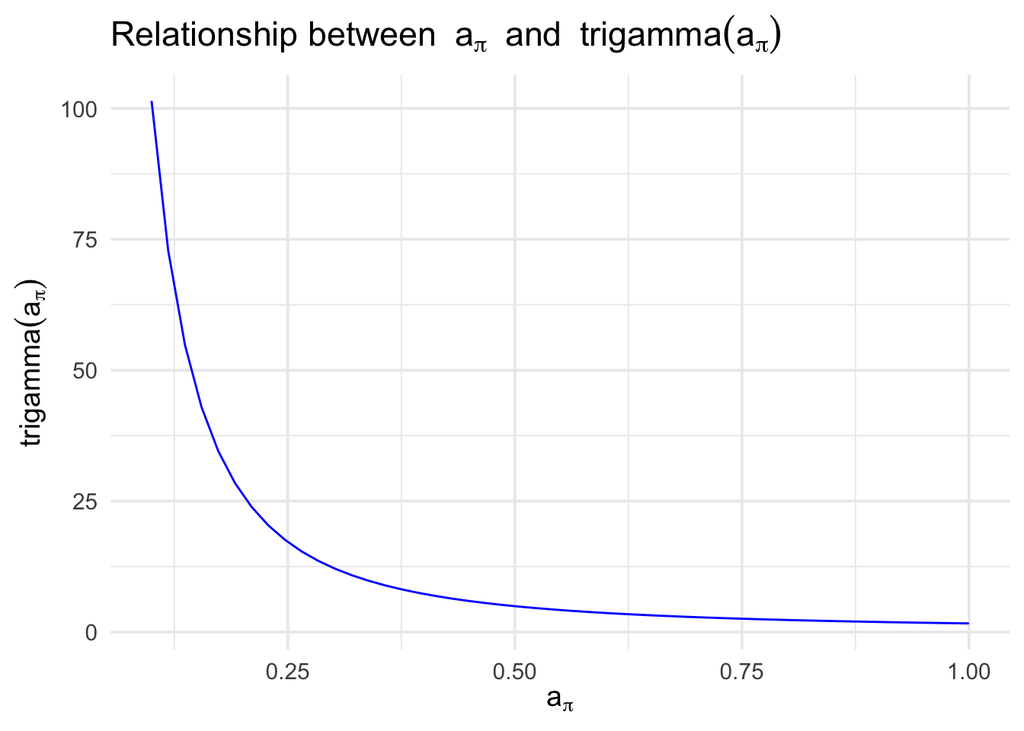

```r
api_values <- seq(0.1, 1, length.out = 50)

trigamma_values <- trigamma(api_values)

# Put into a data frame for ggplot
df <- data.frame(api = api_values, trigamma = trigamma_values)

# Plot
ggplot(df, aes(x = api, y = trigamma)) +
  geom_line(color = "blue") +
  labs(
    x = expression(a[pi]),
    y = expression(trigamma(a[pi])),
    title = expression("Relationship between " ~ a[pi] ~ " and " ~ trigamma(a[pi]))
  ) +
  theme_minimal(base_size = 14)
```

# Posterior plots

In the following we show posterior credibility intervals of the coefficients $b$ and proportions of explained variance $\phi$. We also show posterior predictive plots.

```r
summary_plots <- function(fit, param = "beta", title = "") {
  p1 <- bayesplot::mcmc_intervals(x = fit$draws(param), prob_outer = 0.99)
  p1  + ggtitle(title)
}

pp_plot <- function(fit, title = "") {
  ytilde <- fit$draws("y_tilde_test")
  ytilde <- as.matrix(as_draws_df(ytilde))[, 1:sim_params$ntest]
  I <- sample(1:nrow(ytilde), 100, replace = FALSE)
  ppc_dens_overlay(sim_params$ytest, ytilde[I, ]) +
    ppc_intervals(sim_params$ytest, ytilde[I, ]) +
    ggtitle(title)
}
```

## Parameter Summaries

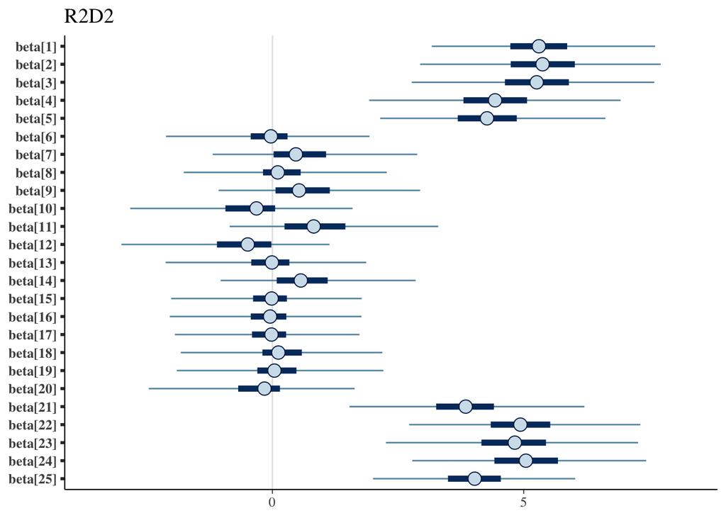

```r
summary_plots(fit_r2d2, "beta", title= "R2D2")
```

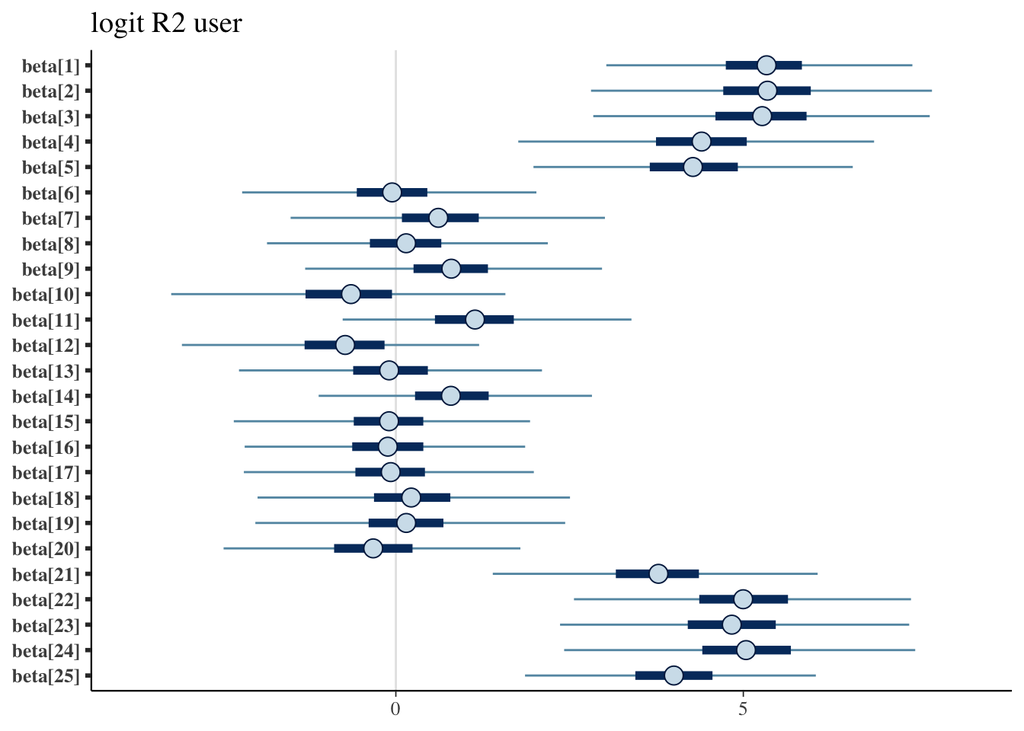

```r
summary_plots(fit_logitr2, "beta", title = "logit R2 user")
```

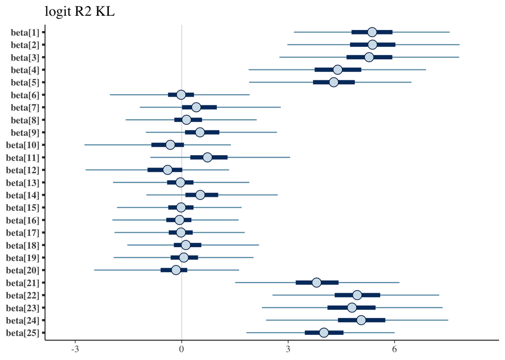

```r
summary_plots(fit_logitr2_kl, "beta", title= "logit R2 KL")
```

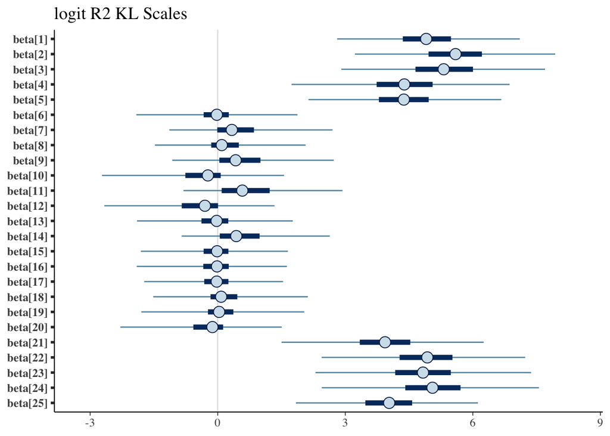

```r
summary_plots(fit_logitr2_kl_scales, "beta", title = "logit R2 KL Scales")
```

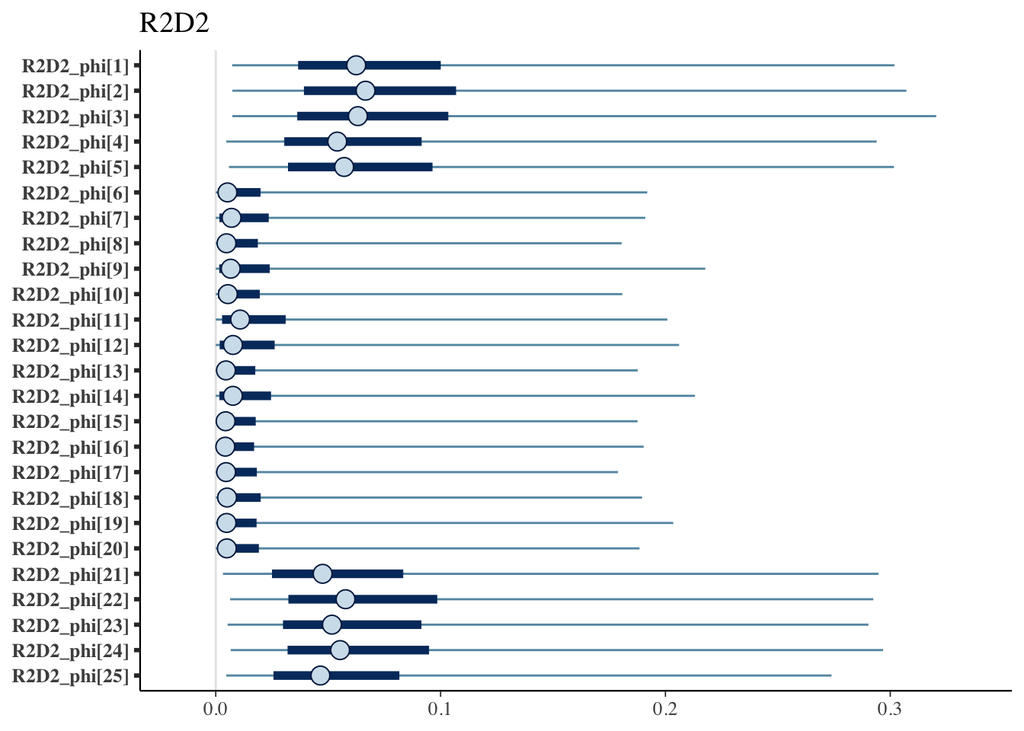

```r
summary_plots(fit_r2d2, "R2D2_phi", title = "R2D2")
```

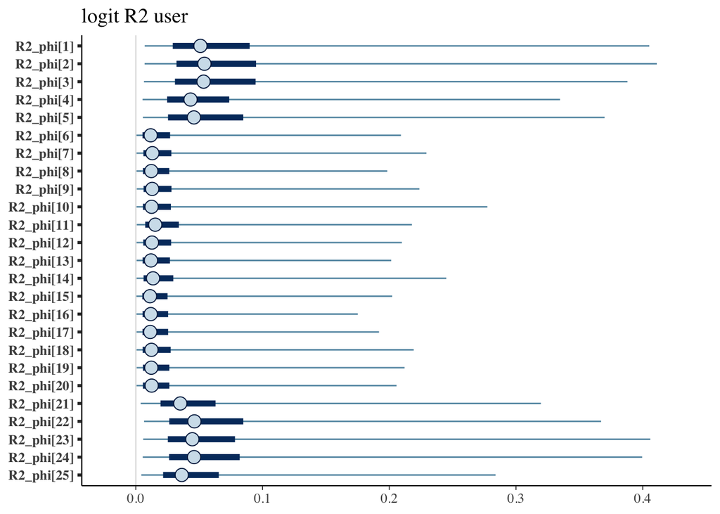

```r
summary_plots(fit_logitr2, "R2_phi", title ="logit R2 user")
```

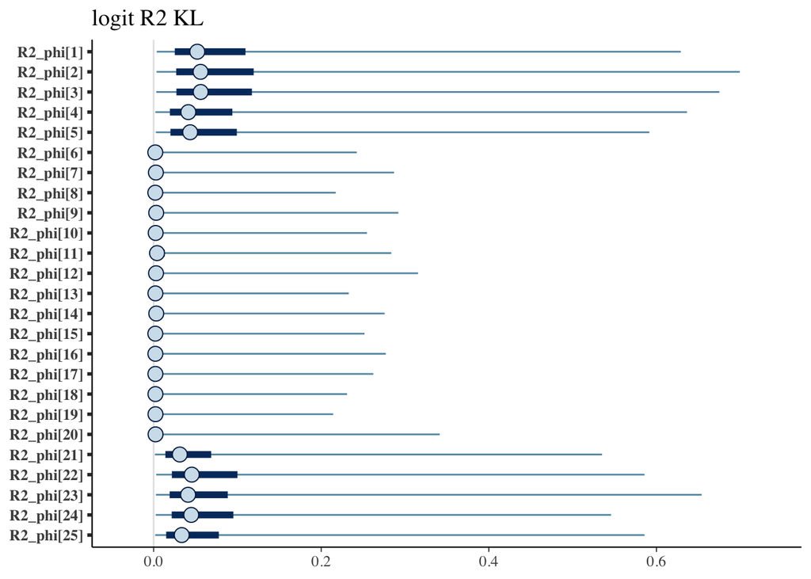

```r
summary_plots(fit_logitr2_kl, "R2_phi", title = "logit R2 KL")
```

[figure not shown]

```r
summary_plots(fit_logitr2_kl_scales, "R2_phi", title =  "logit R2 KL Scales")
```

## Posterior Predictive Checks

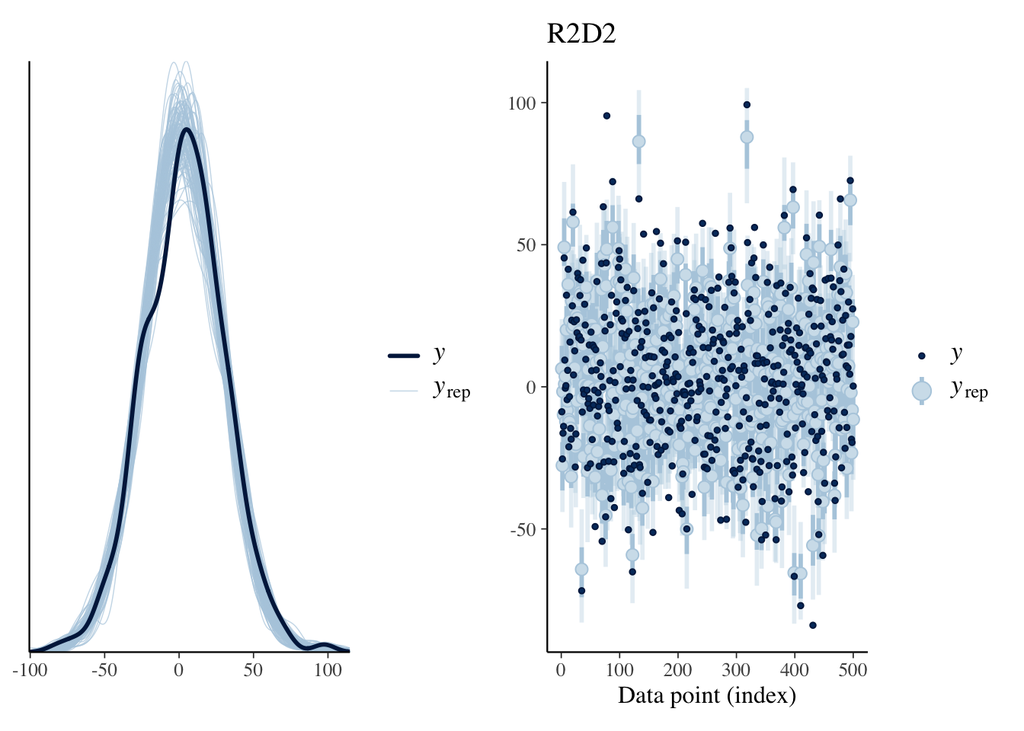

```r
pp_plot(fit_r2d2, title =  "R2D2")
```

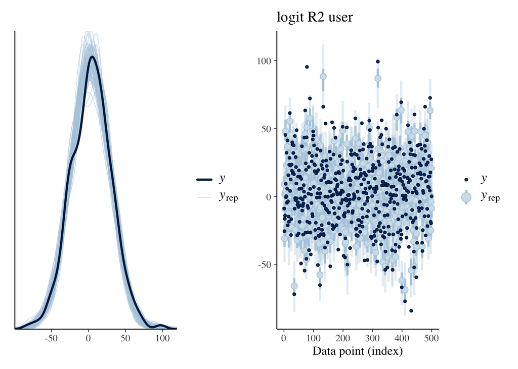

```r
pp_plot(fit_logitr2, title = "logit R2 user")
```

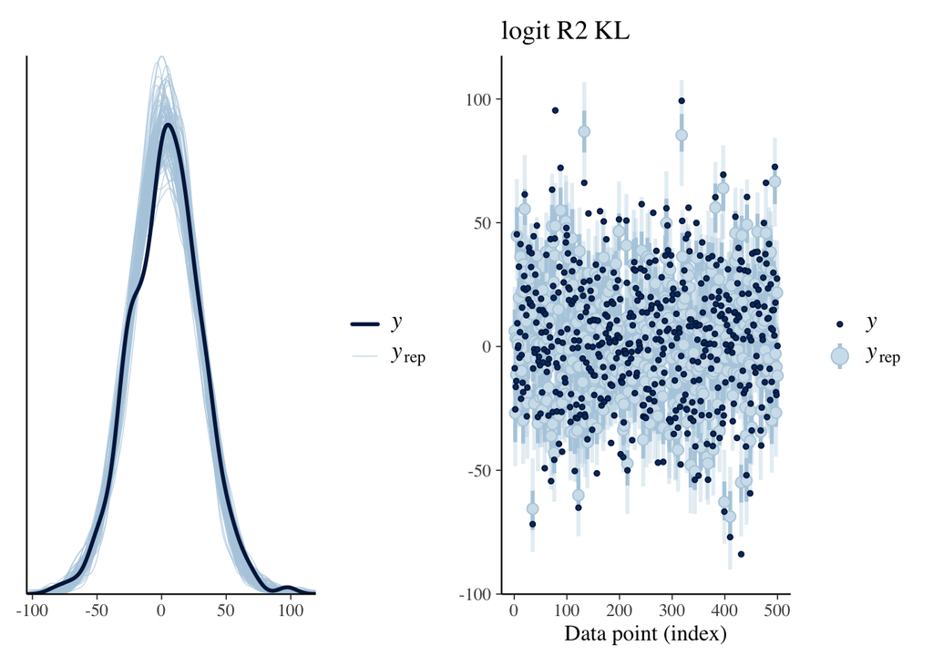

```r
pp_plot(fit_logitr2_kl, title =  "logit R2 KL")
```

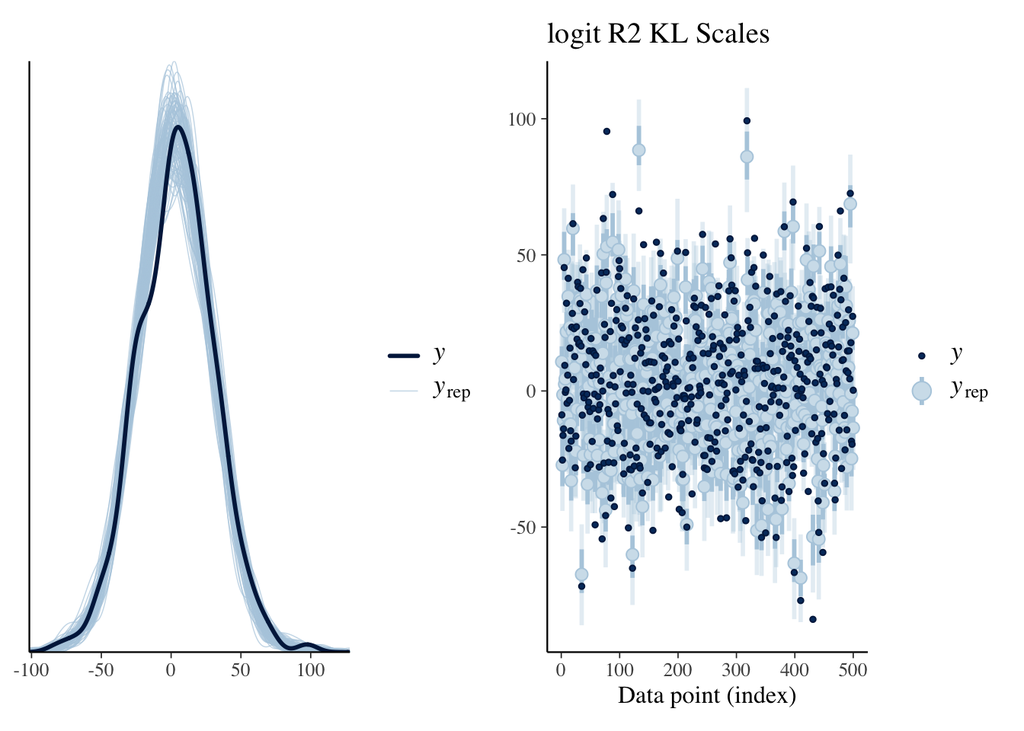

```r
pp_plot(fit_logitr2_kl_scales, title = "logit R2 KL Scales")
```